# MSG analyses

Defu Yap, Geoffrey Brookshire, Daniel Casasanto

# Introduction

Let’s use this script to gather together all the analyses and to generate the plots.

# Method

## Data cleaning

Before all analysis, we excluded non-gestures and emblems. We also excluded gestures that were not produced in the four directions of the stories.

## Analysis

We computed congruity as the proportion of gestures that were in the same direction as the dominant direction of the story.

### Overall congruity

Since there were four possible directions of interest, it would be tempting to treat 25% as chance. However, participants produced unequal numbers of gestures in each direction and each story type, therefore we cannot compare our data against an a priori chance value. To test whether gestures were congruent with the story direction more often than would be expected by chance, we performed within-subjects permutation tests. In each permutation, we randomly shuffled the story direction within each participant’s data 10,000 times, and then computed the congruity over the shuffled data. The permuted distributions are reported as Mean $\pm$ SD.

### Differences in congruity between visibility conditions

We performed a permutation test to determine whether the mean proportion of congruity differs between the different visibility conditions. We computed the variance of the proportion congruity between the three groups, and then randomly shuffled the visibility (experiment) label for each trial ($k = 10,000$).

We performed three separate permutation tests (k=10,000, each) to compare the pairwise differences in gesture congruity between each pair of visibility conditions. We randomly permuted the story directions within each participant, and computed the pairwise differences in congruity.

We performed within-subjects permutations ($k=10,000$) to test whether congruity within each visibility condition was greater than would be expected by chance.

### Congruity within each story direction

We performed bootstrapping tests ($k=1000$) to test whether congruity for each story direction was greater than would be expected by chance. To determine the chance level of congruity, we sampled gestures with replacement within each subject but across all story directions. To ensure that each subject had the same influence over the final congruity estimate, we sampled the same number of gestures as each subject produced in that story direction. We then compared the observed rate of congruity between the observed and predicted gesture directions against the chance level, established by bootstrapping. Effect sizes were reported in odds ratios and their confidence intervals.

### Differences in congruity between input language types

We performed a permutation test to determine whether the mean proportion of congruity differs between the different types of input language. We computed the variance of the proportion congruity between the three groups, and then randomly shuffled the input language label for each trial ($k = 10,000$).

We performed three separate permutation tests (k=10,000, each) to compare the pairwise differences in gesture congruity between each pair of language types. We randomly permuted the story directions within each participant, and computed the pairwise differences in congruity.

We performed within-subjects permutations ($k=10,000$) to test whether congruity within each language type was greater than would be expected by chance.

### Differences in congruity with respect to the presence of directional meaning in clauses.

We performed a permutation test (k=10,000) to compare the pairwise differences in gesture congruity between each pair of clause types. We randomly permuted the story directions within each participant, and computed the pairwise differences in congruity. Then we performed within-subjects permutations tests to test whether congruity within each type of clause (Target vs. Non-target clause) was greater than would be expected by chance ($k=10,000$).

# Results (Combined data)

## Descriptive statistics

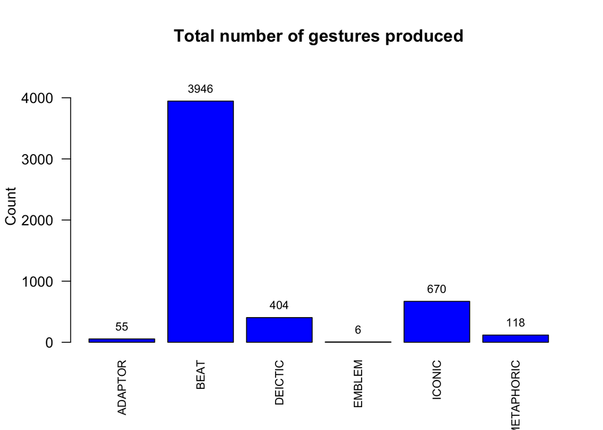

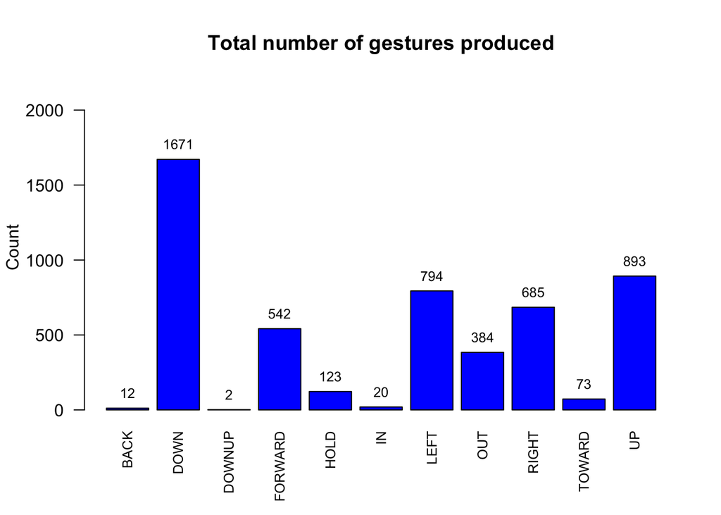

[figure not shown]

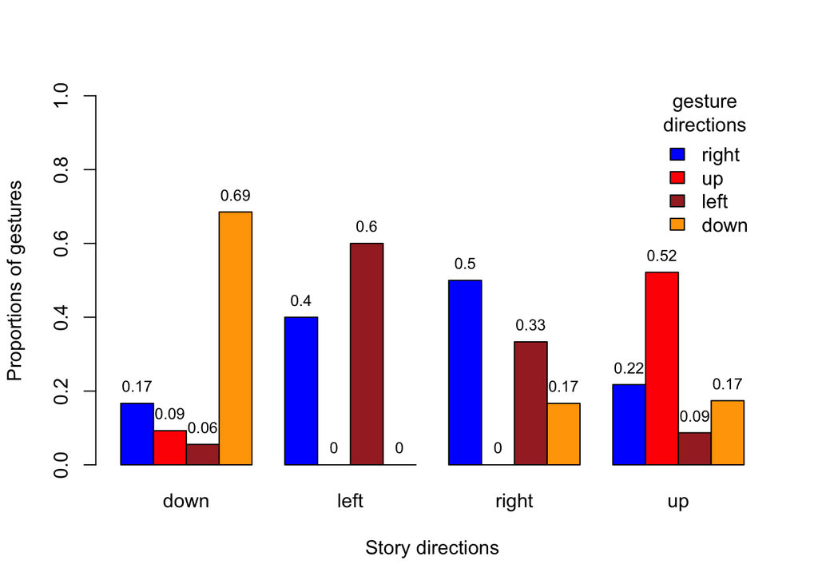

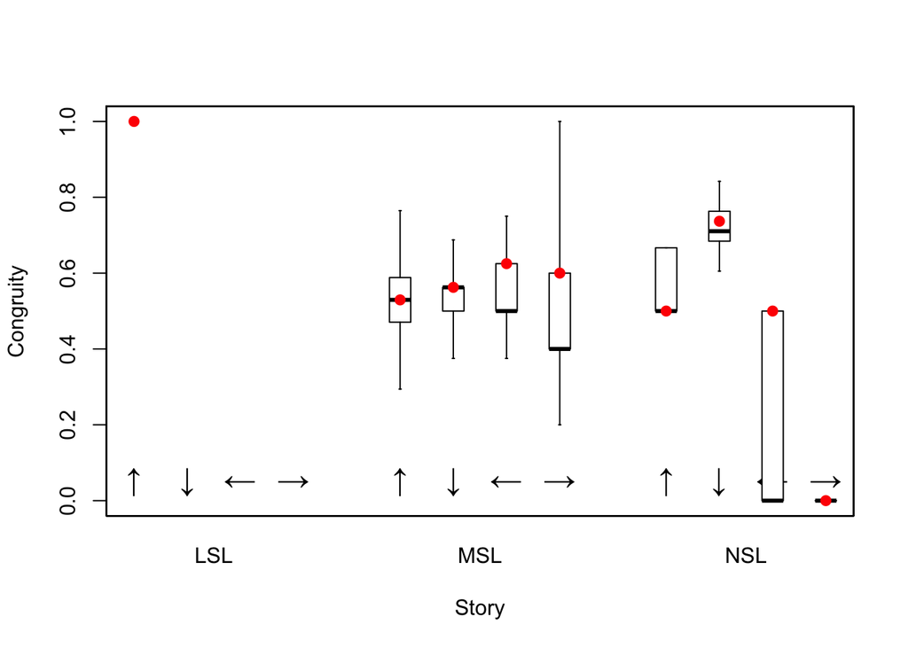